# Formula Sheet

Jeff Nguyen

17/11/2020

**Economic**  
For Linear Model, Price Elasticity of Demand $\xi_p = \frac{\Delta q\%}{\Delta p\%} = \frac{\Delta q}{\Delta p}*\frac{p}{q}$  
where $e<1$: necessity (inelastic), $e>1$: luxury, $e=1$: unit elastic

**Ratios**
$$\begin{equation}
\begin{aligned}
\text{Semi-Variance} SV(x) & = (\sigma_{semi})^2 = \frac{\sum min((R_t - \overline R), 0)^2}{T} \\
\text{Lower Partial Moment} LPM2(x)_\tau & = \frac{\sum min((R_t - R_{\tau}), 0)^2}{T} \\
\text{Coefficient of variation} CV & = \frac{\sigma}{\mu} \\
\text{Sharpe Ratio} S_{JPM} & = \frac{E(r_p) - r_f}{\sigma_p} \\
\text{Sortino Ratio} SortinoRatio & = \frac{r_p - r_f}{\sigma_{downside}} \\
\text{Treynor Ratio} TreynorRatio & = \frac{r_p - r_f}{\beta_p} \\
Cov_{X,Y} & = \sum_{i=1}^{n} \frac{(X_i - \overline{X}) * (Y_i - \overline{Y})}{n-1} \\
Corr_{X,Y} & = \frac{Cov_{X,Y}}{\sigma_X * \sigma_Y} \\
\end{aligned}
\end{equation}$$

**Value at Risk**
Step 1: Get Scaling Factor 1: ‘1 year’, 1/2: ‘6 months’, 1/12: ‘1 month’, 1/250: ‘1 day’
Step 2: Calculate scaled mean returns $\mu_{scaled} = \mu*scalingFactor$
Step 3: Calculate scaled standard deviation $\sigma_{scaled} = \sigma*\sqrt{scalingFactor}$
Step 4: Look up the $z_{statistics} = 1 - VaR$
Step 5: $VaR = \mu_{scaled} + \sigma_{scaled} * z_{statistics}$
Others:
$$\begin{equation}
\begin{aligned}
\text{Risk Adjusted Portfolio} \quad RAP & = \sum \beta_i*R_i \\
\text{Equity VaR} \quad EVaR & = RAP * VaR \\
\text{Global Minimum Variance Solution} \quad w_1 & = \frac{\sigma_{22} - \sigma_{12}}{\sigma_{11} + \sigma_{22} - 2\sigma_{12}} \\
\text{Return of portfolio} \quad R_p & = w_1.R_1 + w_2.R_2 \\
\text{Standard Deviation of Portfolio} \quad \sigma_{p} & = \sqrt{\sigma_1^2(w_1^2) + \sigma_2^2(w_2^2) + 2(w_1)(w_2)\sigma_{12}} \\
\text{Portfolio function} \quad Y & = R_f + \frac{R_p - R_f}{\sigma_p}*X \\
\text{Covariance} \quad \sigma_{12} &= \rho_{12} * \sigma_1 * \sigma_2 \quad \text{where} \rho_{12} \text{ is the correlation} \\
\end{aligned}
\end{equation}$$

**Lagrangian Function - Finance (2 stocks)**
Markowitz portfolio Formulate the problem: $min \sigma^2_p = w_1^2\sigma_{11} + w_2^2\sigma_{22} + 2w_1w_2\sigma_{12}$ s.t. $w_1R1 + w_2R_2 \geqslant R_f$
Step 1: Solve the Lagrangian $L = w_1^2\sigma_{11} + w_2^2\sigma_{22} + 2w_1w_2\sigma_{12} + \lambda(R_f-w_1R_1 - w_2R_2)$
Step 2: Differentiate L wrt. $w_1$, $w_2$ and $\lambda$ or use the formula:
$$\begin{equation}
\begin{aligned}
w_1 &= \frac{\sigma_{22}(R_1 - R_f) - \sigma_{12}(R_2-R_f)}{\sigma_{11}\sigma_{22} - \sigma^2_{12}} \\
w_2 &= \frac{\sigma_{11}(R_2 - R_f) - \sigma_{12}(R_1-R_f)}{\sigma_{11}\sigma_{22} - \sigma^2_{12}} \\
\end{aligned}
\end{equation}$$
Step 3: Normalize $w_1$, $w_2$ to find $w_p = \frac{w_1}{w_1+w_2}$
Step 4: Returns of the tangency portfolio $R_p = R_1w_p + R_2(1 - w_p)$
Step 5: Risk of the tangency portfolio $\sigma_p = \sqrt{\sigma_{11}w_p^2 + \sigma_{22}(1 - w_p)^2 + 2w_p(1-w_p)\sigma_{12}}$
Step 6: $Sharpe Ratio = \frac{(R_p - R_f)}{\sigma_p}$
Step 7: The efficient frontier equation: $Y = R_f + Sharpe*X$
Step 8: Capital Allocation Line connects the risk-free asset to the tangency point $R = R_f + \lambda\sigma$ with $\sigma=Sharpe$ and $\lambda = \frac{R_p - R_f}{\sigma_p}$

**Lagrangian Function - Finance (3 stocks)**  
Objective: $min \quad \sigma^2_p = w'\sum w$ s.t. $w'R \geqslant R_f$  
Note: $w$, $R$ is a column vector. Dual to the problem: $max \quad R_p = w'R$ s.t. $w'\sum w \leqslant \sigma$  
SteP 1: Form the Lagragian function: $L = w'\sum w + \lambda(R_f - w'R)$  
Step 2: Partially differentiate w.r.t. w to solve for 1st order condition result in the z vector $z = \sum^{-1}*(R-R_f)$  
Step 3: $\lambda = sum(z)$  
Step 4: Normalized weights $w_i = \frac{z_i}{\lambda}$  
Step 5: Portfolio return is: $R_p = \sum w_iR_i$  
Step 6: Portfolio variance is: $\sigma^2_p = w'\sum w = w_1^2\sigma_{11} + w_2^2\sigma_{22} + w_3^2\sigma_{33} + 2w_1w_2\sigma_{12} + 2w_2w_3\sigma_{23} + 2w_3w_1\sigma_{31}$  
Step 7: Slop of the Capital Alocation Line: $slope = \frac{R_p - r_f}{\sqrt{\sigma^2_p}}$  
Step 8: Formulate CAL: $CAL = r_f + slope*x$  
Step 9: Tangency point is where the optimum weight is $(\sigma_p, R_p)$

**Standard Form of Presenting Regression Result**
$$\begin{equation}
\begin{aligned}
\hat{Y} =& \hat{\beta_0} + \hat{\beta_1}*X \\
\\
\text{Coefficients} \\
\text{X} \quad \hat{\beta_1} =& \frac{\sum xy}{\sum x^2} \quad \text{add conclusion of positive-> positive relationship and vice versa} \\
\text{intercept} \quad \hat{\beta_0} =& \overline y - \hat{\beta_1} * \overline x \\
\\
\text{Statistics} \\
R^2 =& \hat{\beta_1}^2 * \frac{\sum x^2}{\sum y^2} \\
SE_{Regression} =& \sqrt{\frac{(\sum y^2) - \hat{\beta_1}^2 * (\sum x^2)}{n-2}} \\
\\
\text{Forecasting Efficiency} \\
S_{\hat{\beta_1}} =& \frac{SE_{Regression}}{\sqrt{\sum x^2}} \\
t_{\hat{\beta_1}} =& \frac{\hat{\beta_1}}{S_{\hat{\beta_1}}} \\
\\
\text{To compare with a fix constant for hypothesis testing:}
t = \frac{\hat{\beta_1} - C_{H_0}}{S_{\hat{\beta_1}}} \\
\text{Null Hypothesis} \, \beta_1 =& C_{H_0} \\
\text{Alternative Hypothesis} \, \beta_1 \neq& C_{H_0} \\
\text{If} \, t > t_{critical} \, \text{reject the null hypothesis, otherwise, fail to reject the null} \\
\\
S_{\hat{\beta_0}} =& S_{\hat{\beta_1}}*\sqrt{\frac{\sum X^2}{n}} \\
t_{\hat{\beta_0}} =& \frac{\hat{\beta_0}}{S_{\hat{\beta_0}}} \\
\\
\text{Forecasting} \\
\text{Given} \, X_F \\
Y_F =& \hat{\beta_0} + \hat{\beta_1} * X_F \\
SE_{F} =& SE_{Regression} * \sqrt{1 + \frac{1}{n} + \frac{\sum (X_F - \overline X)^2}{\sum x^2}} \\
\text{High} \, R^2 \, \text{means more errors.} \\
\text{More observations means smaller errors.} \\
\text{If} \, n>40 \, \text{use} \, t_critical = Z \, \text{instead} \\
\text{Confidence Interval of Forecasting} & \, P(Y_F - t_{critical} * SE_F) \leqslant Y_F \leqslant P(Y_F + t_{critical} * SE_F) \\
\text{Expected Returns} \, =& \overline{r_f} + \hat{\beta_0} + \hat{\beta_1} * X_F \, \hat{beta_0} = 0 \, \text{if insignificant, failed to reject null, p-value > .05} \\
\end{aligned}
\end{equation}$$

**Statistics of Forecasting**
$$\begin{equation}
\begin{aligned}
\text{Random Walk/ Naive} \\
\epsilon =& Y_t - Y{t-1} \\
\\
\text{MAD (Mean Absolute Deviation)} \\
MAD =& \frac{\sum \epsilon_i}{n} \\
\\
\text{MAPE (Mean Absolute Percent Error)} \\
MAPE =& \frac{\sum |\frac{\epsilon_t}{Y_t}|}{n} \\
\\
\text{RMSE (Real Mean Squared Error)} \\
RMSE =& \sqrt{\frac{\sum \hat{\epsilon}^2}{n}} \\
\\
\text{MASE (Mean Absolute Scaled Error)} \\
MASE =& \frac{MAD}{\frac{1}{T-1} * \sum |Y_t - Y_{t-1}|} \\
\\
\text{In-sample Forecasting (ex-post, unconditional)} \\
SE_F =& SE_{Regression} * \sqrt{\frac{1}{n} + \frac{(X_F - \overline{X})^2}{\sum{x^2}}} \\
\\
\text{Out-of-sample Forecasting (ex-ante, conditional)} \\
SE_F =& SE_{Regression} * \sqrt{1 + \frac{1}{n} + \frac{(X_F - \overline{X})^2}{\sum{x^2}}} \\
\end{aligned}
\end{equation}$$

Simple linear regression

```r
# Simple linear regression
x <- c(1, 4, 2, 3, 5)
y <- c(3, 2, 3, 2.5, 2)
data <- cbind(x, y)

fit <- lm(y~x)
summary(fit)
```

```
##
## Call:
## lm(formula = y ~ x)
##
## Residuals:
##          1          2          3          4          5
## -1.000e-01 -2.000e-01  2.000e-01 -2.151e-16  1.000e-01
##
## Coefficients:
##             Estimate Std. Error t value Pr(>|t|)
## (Intercept)  3.40000    0.19149  17.756 0.000389 ***
## x           -0.30000    0.05774  -5.196 0.013847 *
## ---
## Signif. codes:  0 '***' 0.001 '**' 0.01 '*' 0.05 '.' 0.1 ' ' 1
##
## Residual standard error: 0.1826 on 3 degrees of freedom
## Multiple R-squared:    0.9,  Adjusted R-squared:  0.8667
## F-statistic:    27 on 1 and 3 DF,  p-value: 0.01385
```

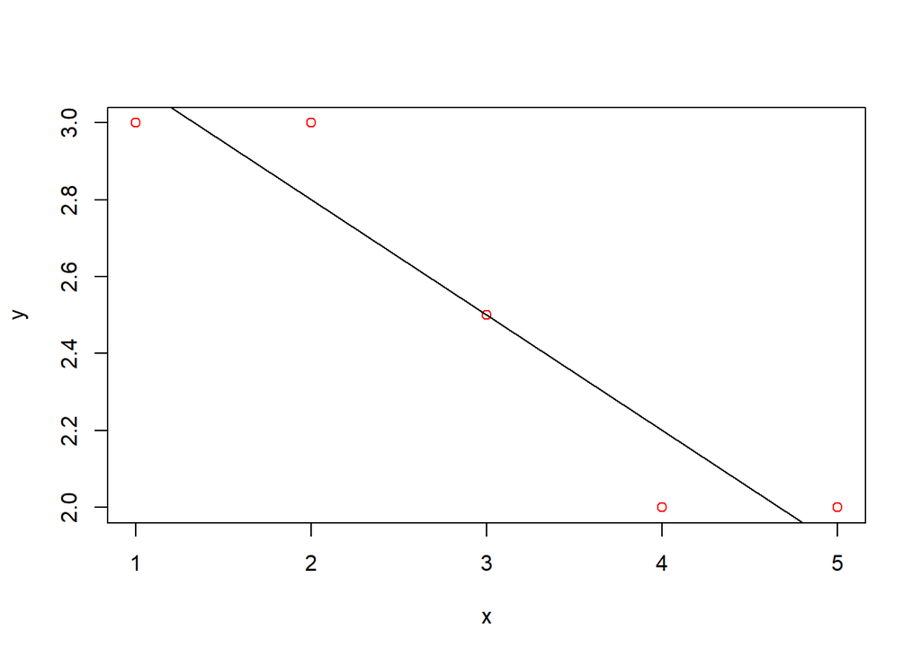

```r
plot(x, y, col="red")
abline(lm(y ~ x))
```

Log linear

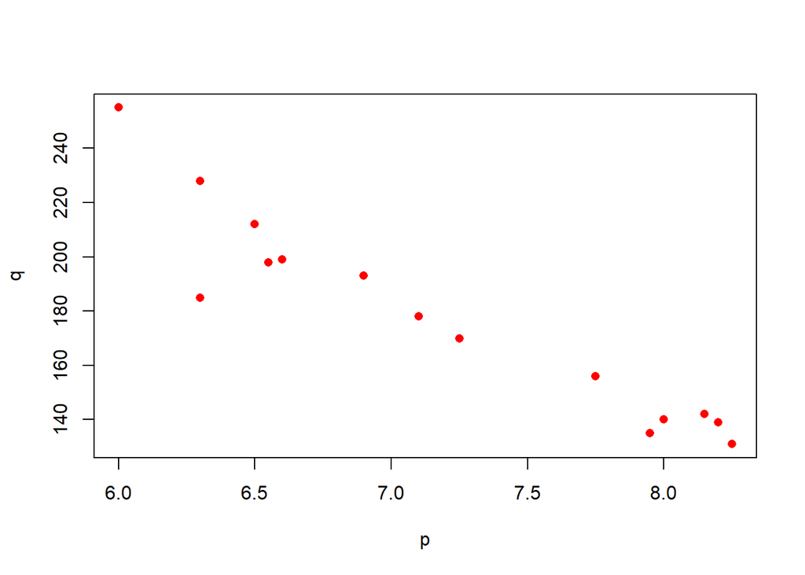

```r
# Log linear
# Price, quantity and the corresponding data file
p <- c(6,6.30,6.50,6.55,6.30,8,7.95,8.25,7.10,7.25,6.90,6.60,8.15,7.75,8.20)
q <- c(255,228,212,198,185,140,135,131,178,170,193,199,142,156,139)
data_demand <- data.frame(p, q)

plot(p,q, pch = 16, cex = 1, col = "red", xlab = "p", ylab = "q")
```

```r
fit_linear <- lm(q~p)
summary(fit_linear)
```

```
##
## Call:
## lm(formula = q ~ p)
##
## Residuals:
##      Min       1Q   Median       3Q      Max
## -31.6074  -4.4706   0.6194   5.3224  25.1269
##
## Coefficients:
##             Estimate Std. Error t value Pr(>|t|)
## (Intercept)  495.186     30.549   16.21 5.28e-10 ***
## p            -44.219      4.226  -10.46 1.06e-07 ***
## ---
## Signif. codes:  0 '***' 0.001 '**' 0.01 '*' 0.05 '.' 0.1 ' ' 1
##
## Residual standard error: 12.64 on 13 degrees of freedom
## Multiple R-squared:  0.8938, Adjusted R-squared:  0.8857
## F-statistic: 109.5 on 1 and 13 DF,  p-value: 1.062e-07
```

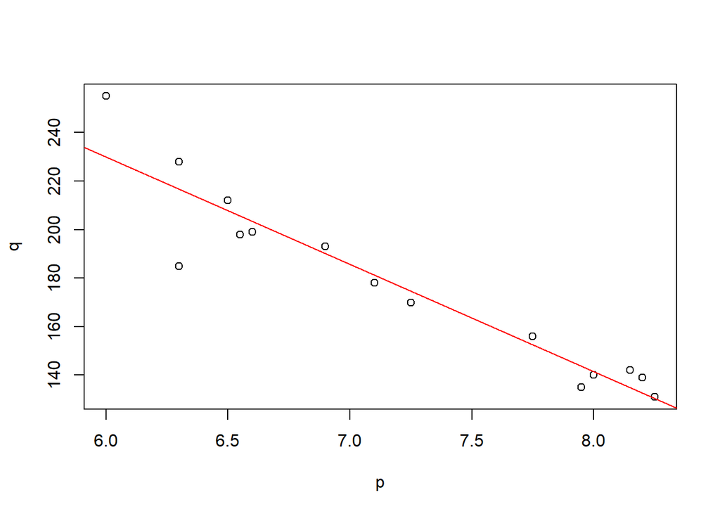

```r
plot(p, q)
abline(lm(q~p), col="red")
```

```r
fit_log_linear <- lm(log(q)~log(p))
summary(fit_log_linear)
```

```
##
## Call:
## lm(formula = log(q) ~ log(p))
##
## Residuals:
##      Min       1Q   Median       3Q      Max
## -0.16335 -0.01959  0.01231  0.03545  0.07012
##
## Coefficients:
##             Estimate Std. Error t value Pr(>|t|)
## (Intercept)   8.6822     0.2771   31.33 1.24e-13 ***
## log(p)       -1.7921     0.1407  -12.74 1.02e-08 ***
## ---
## Signif. codes:  0 '***' 0.001 '**' 0.01 '*' 0.05 '.' 0.1 ' ' 1
##
## Residual standard error: 0.05873 on 13 degrees of freedom
## Multiple R-squared:  0.9258, Adjusted R-squared:  0.9201
## F-statistic: 162.2 on 1 and 13 DF,  p-value: 1.019e-08
```

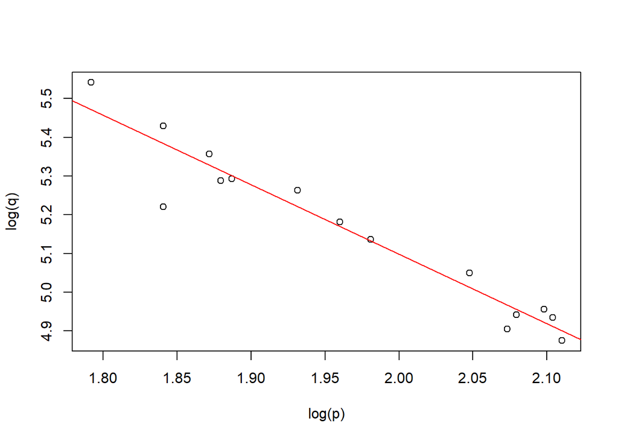

```r
plot(log(p), log(q))
abline(lm(log(q)~log(p)), col = "red")
```

Polynomials model

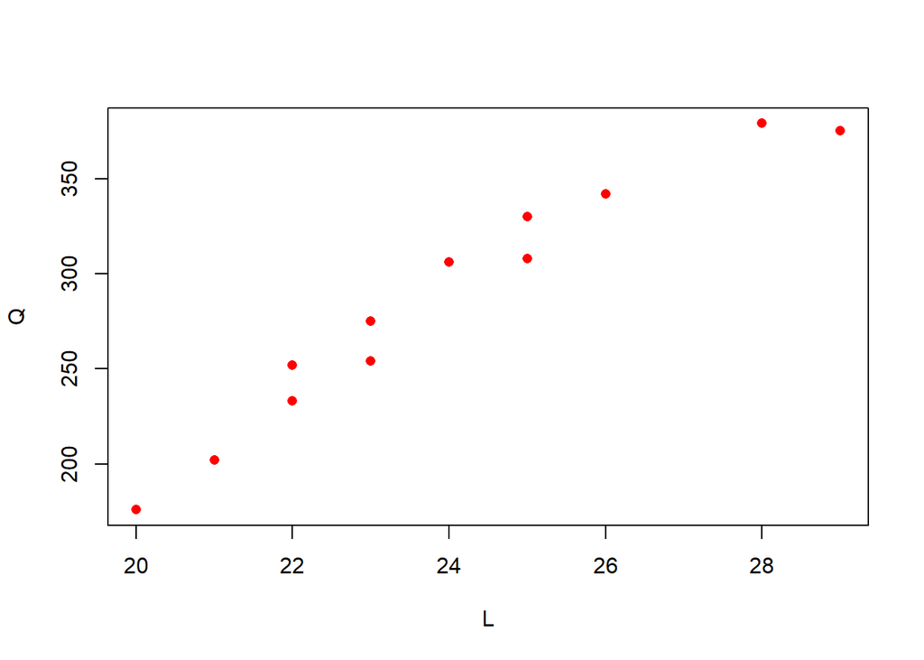

```r
# Production data:
L <- c(23,21,22,    26, 28, 25, 23, 20, 22, 24, 25, 29)
Q <- c(254,202,252,342,379,330,275,176,233,306,308,375)

production <- data.frame(Q, L)
plot(L,Q,col='red', pch = 16, cex = 1)
```

```r
# Estimating the production function.
Z <- L^2
production <- lm(Q~Z)   #An alternative is estimating the model as production <- lm(Q~ L^2)
summary(production)
```

```
##
## Call:
## lm(formula = Q ~ Z)
##
## Residuals:
##      Min       1Q   Median       3Q      Max
## -31.4236  -9.6341   0.7477  12.9341  24.3311
##
## Coefficients:
##             Estimate Std. Error t value Pr(>|t|)
## (Intercept) 14.13333   25.60866   0.552    0.593
## Z            0.46646    0.04291  10.871 7.35e-07 ***
## ---
## Signif. codes:  0 '***' 0.001 '**' 0.01 '*' 0.05 '.' 0.1 ' ' 1
##
## Residual standard error: 19.11 on 10 degrees of freedom
## Multiple R-squared:  0.922,  Adjusted R-squared:  0.9142
## F-statistic: 118.2 on 1 and 10 DF,  p-value: 7.354e-07
```

Rational model

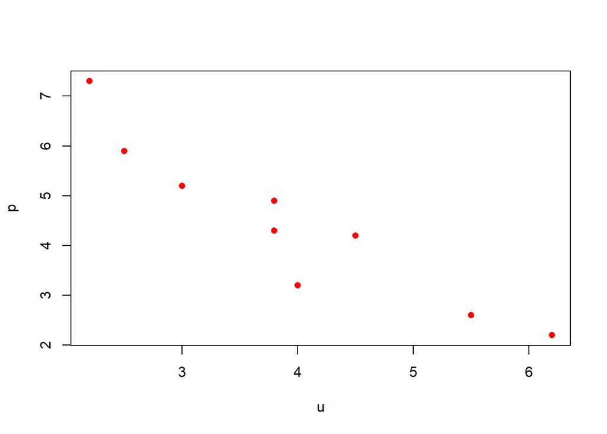

```r
u   <- c(3.0,   4.5,    4.0,    3.8,    2.5,    2.2,    3.8,    4.5,    5.5,    6.2)
p   <- c(5.2,   4.2,    3.2,    4.9,    5.9,    7.3,    4.3,    4.2,    2.6,    2.2)
datafile <- data.frame(u, p)

plot(u, p, col="red", pch=16, cex=1)
```

```r
# Estimating the Phillips curve:
z <- 1/u
Phillips <- lm(p~(z))
summary(Phillips)
```

```
##
## Call:
## lm(formula = p ~ (z))
##
## Residuals:
##      Min       1Q   Median       3Q      Max
## -0.81324 -0.40472 -0.00444  0.49621  0.68462
##
## Coefficients:
##             Estimate Std. Error t value Pr(>|t|)
## (Intercept)   0.1725     0.5660   0.305    0.768
## z            15.3631     1.9568   7.851    5e-05 ***
## ---
## Signif. codes:  0 '***' 0.001 '**' 0.01 '*' 0.05 '.' 0.1 ' ' 1
##
## Residual standard error: 0.5512 on 8 degrees of freedom
## Multiple R-squared:  0.8851, Adjusted R-squared:  0.8708
## F-statistic: 61.64 on 1 and 8 DF,  p-value: 4.997e-05
```

Multiple Regression

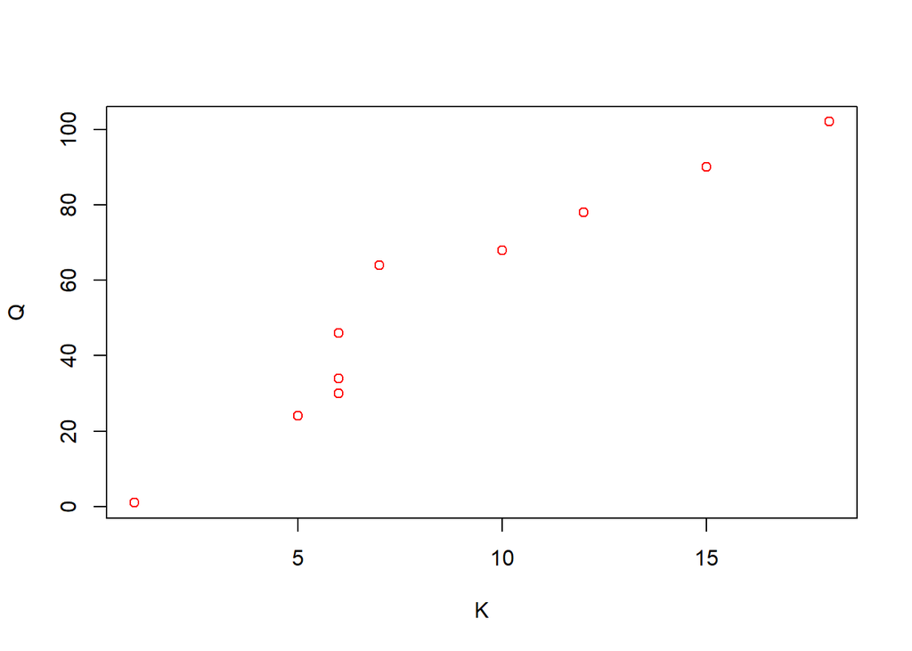

```r
#   Plot Q against K.

N   <- c(1, 2,  3,  5,  6,  9,  12, 14, 15, 15, 15)
K   <-c(1,  5,  6,  6,  6,  7   ,10,    10, 12, 15, 18)
Q   <- c(1, 24, 30, 34, 46, 64, 68, 68, 78, 90, 102)


plot(x=K, y=Q, col="red")
```

```r
fit <- lm(Q~N+K)
summary(fit)
```

```
##
## Call:
## lm(formula = Q ~ N + K)
##
## Residuals:
##     Min      1Q  Median      3Q     Max
## -8.0525 -3.0619 -0.6292  0.4064 14.0733
##
## Coefficients:
##             Estimate Std. Error t value Pr(>|t|)
## (Intercept)   3.1381     4.3542   0.721   0.4916
## N             2.6937     0.8719   3.090   0.0149 *
## K             3.2207     1.0037   3.209   0.0124 *
## ---
## Signif. codes:  0 '***' 0.001 '**' 0.01 '*' 0.05 '.' 0.1 ' ' 1
##
## Residual standard error: 6.788 on 8 degrees of freedom
## Multiple R-squared:  0.9608, Adjusted R-squared:  0.951
## F-statistic: 98.06 on 2 and 8 DF,  p-value: 2.36e-06
```

Interpolating polynomials

```r
x <-c(1,3,5,8)
y <- c(5,3,6,8)
lm(x ~ y + I(y^2) + I(y^3))
```

```
##
## Call:
## lm(formula = x ~ y + I(y^2) + I(y^3))
##
## Coefficients:
## (Intercept)            y       I(y^2)       I(y^3)
##      76.000      -45.833        8.667       -0.500
```

Ex-post

```r
x <- c(2300, 2360, 2395, 2407, 2389, 2430, 2395, 2413, 2430, 2467, 2480, 2490)
y <-    c(2145, 2173, 2189, 2190, 2185, 2206, 2195, 2215, 2235, 2251, 2279, 2281)
dat <- data.frame(y, x)

fit <- lm(y~x)
fit
```

```
##
## Call:
## lm(formula = y ~ x)
##
## Coefficients:
## (Intercept)            x
##    380.8665       0.7589
```

```r
data1 <- dat[1:10,]
data2 <- dat[11:12,]
fit1 <- lm(y~x, data=data1)
fit1
```

```
##
## Call:
## lm(formula = y ~ x, data = data1)
##
## Coefficients:
## (Intercept)            x
##    677.8486       0.6339
```

```r
pred <- predict(fit1, newdata=data2)
pred
```

```
##       11       12
## 2250.002 2256.341
```

Ex-ante

```r
library(forecast)
x <- c(2300, 2360, 2395, 2407, 2389, 2430, 2395, 2413, 2430, 2467, 2480, 2490)
y <-    c(2145, 2173, 2189, 2190, 2185, 2206, 2195, 2215, 2235, 2251, 2279, 2281)
dat <- data.frame(y, x)
data1 <- dat[1:10,]
data2 <- dat[11:12,]
fore <- forecast(fit, newdata=data.frame(x=c(mean(x), mean(y)), se.fit=TRUE))
fore
```

```
##   Point Forecast    Lo 80    Hi 80    Lo 95    Hi 95
## 1       2212.000 2193.499 2230.501 2181.959 2242.041
## 2       2059.469 2031.948 2086.989 2014.781 2104.156
```